# Overfitting and Regularization

## Imports

```python
import numpy as np
import pandas as pd
import seaborn as sns
import matplotlib.pyplot as plt
```

```python
from sklearn.pipeline import Pipeline
from sklearn.model_selection import train_test_split, cross_validate, GridSearchCV
from sklearn.preprocessing import PolynomialFeatures, StandardScaler
from sklearn.linear_model import LinearRegression, Lasso, Ridge
from sklearn.metrics import mean_squared_error
from sklearn.compose import ColumnTransformer
from sklearn import set_config
```

```python
set_config(display='diagram')
```

## Settings

```python
SEED = 42
RANGE = (-5, 5)
N_SAMPLES = 50
DEGREES = np.linspace(0, 15, 1 + 15, dtype=int)
ALPHAS = np.linspace(0, 0.5, 1 + 40)
```

## Part 1: Underfitting vs. overfitting

### Generate samples

Let's pick a target function $ f(x) = 2\cdot x + 10\cdot sin(x) $ and generate some noisy samples to learn from.

```python
def target_function(x):
    return 2 * x + 10 * np.sin(x)

def generate_samples():
    """Generate noisy samples."""
    np.random.seed(SEED)
    x = np.random.uniform(*RANGE, size=N_SAMPLES)
    y = target_function(x) + np.random.normal(scale=4, size=N_SAMPLES)
    return x.reshape(-1, 1), y

X, y = generate_samples()
```

### Plot samples

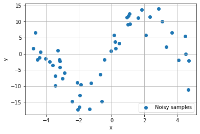

```python
def plot_scatter(x, y, title=None, label='Noisy samples'):
    plt.scatter(x, y, label=label)
    plt.xlabel('x')
    plt.ylabel('y')
    plt.grid(True)
    plt.title(title)
    plt.legend(loc='lower right')

plot_scatter(X, y)
```

### Split

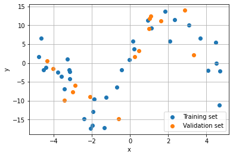

```python
X_train, X_valid, y_train, y_valid = train_test_split(X, y, test_size=0.3, random_state=SEED)

plot_scatter(X_train, y_train, label='Training set')
plot_scatter(X_valid, y_valid, label='Validation set')
```

```python
y_train
```

```
array([ -1.10771616,   0.84986647,  -9.62110024,   3.70972424,
        -2.36319095,   5.83708039, -16.53330524,  -1.8815588 ,
       -11.1506254 ,   1.0883081 ,  -9.05957818, -14.72254274,
         5.71746212,   5.48508317,  -6.81897956,  -1.80751907,
        -2.14124891, -12.83476672,  -0.09034969,  -3.48222266,
        11.50001273,  -2.03019037,  10.03142993, -17.18409407,
        -2.48182149,   1.67461593, -17.32081894,  -6.32825039,
        -4.15121484,   9.31494651,   6.5817456 ,   6.58351686,
        -1.83803375,  11.27589865,  13.68530977])
```

### Model

Let's try to approximate our target function $ f(x) = 2\cdot x + 10\cdot sin(x) $ with polynomials of different degree.

A polynomial of degree $n$ has the form: $ h(x) = w_0 + w_1\cdot x + w_2\cdot x^2 +\ldots + w_n\cdot x^n $.

$x^i$ values could easily be generated by `PolynomialFeatures`, while $w_i$ are the unknown paramaters to be estimated using `LinearRegression`.

```python
PolynomialFeatures(degree=4, include_bias=False).fit_transform(X=[
    [1],
    [3],
    [4],
])
```

```
array([[  1.,   1.,   1.,   1.],
       [  3.,   9.,  27.,  81.],
       [  4.,  16.,  64., 256.]])
```

```python
def make_model(degree, alpha=0, penalty=None):
    # linear regression
    if alpha == 0:
        regressor = LinearRegression()
    # lasso regression",
    elif penalty == 'L1':
        regressor = Lasso(alpha=alpha, random_state=SEED, max_iter=50000)
    # ridge regression",
    elif penalty == 'L2':
        regressor = Ridge(alpha=alpha, random_state=SEED, max_iter=50000)

    return Pipeline([
        ('pol', PolynomialFeatures(degree, include_bias=(degree == 0))),
        ('sca', StandardScaler()),
        ('reg', regressor)
    ])

display(make_model(2))
display(make_model(2, penalty='L1', alpha=0.1))
display(make_model(2, penalty='L2', alpha=0.1))
```

### Fit

Let's fit a model and plot the hypothesis it learns:

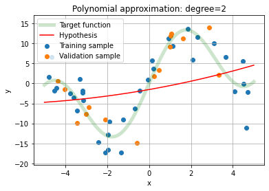

```python
def plot_fit(model):
    degree = model['pol'].degree
    X_range = np.linspace(*RANGE, 1000).reshape(-1, 1)
    y_pred = model.predict(X_range)
    plot_scatter(X_train, y_train, label='Training sample')
    plot_scatter(X_valid, y_valid, label='Validation sample')
    plt.plot(X_range, target_function(X_range), c='green', alpha=0.2, lw=5, label='Target function')
    plt.plot(X_range, y_pred, c='red', label='Hypothesis')
    plt.ylim((min(y) - 3, max(y) + 3))
    plt.legend(loc='best')
    plt.title(f'Polynomial approximation: degree={degree}')
    plt.show()

plot_fit(make_model(degree=2).fit(X_train, y_train))
```

### From underfitting to overfitting

We can investigate the shape of the fitted curve for different values of `degree`:

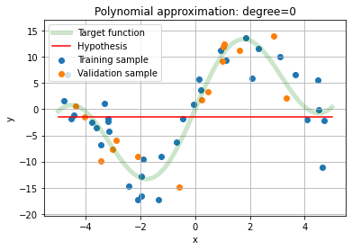

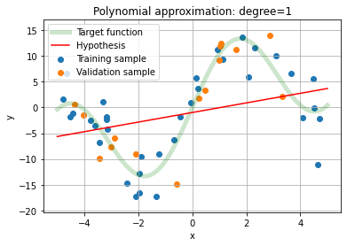

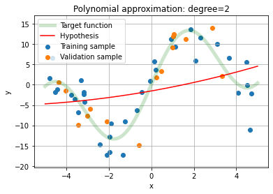

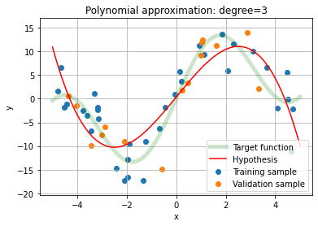

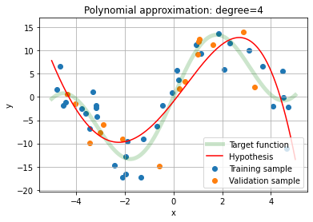

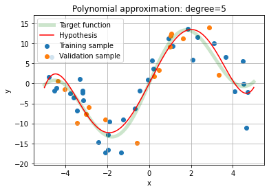

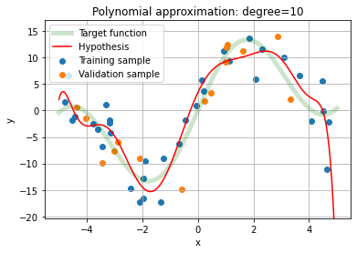

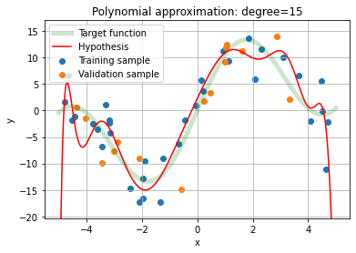

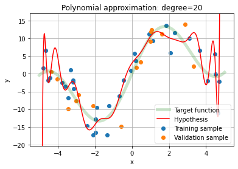

```python
for degree in [0, 1, 2, 3, 4, 5, 10, 15, 20]:
    plot_fit(make_model(degree).fit(X_train, y_train))
```

### Fitting graph

In the next step we calculate the training and the validation error for each `degree` and plot them in a single graph. The resulting graph is called the fitting graph.

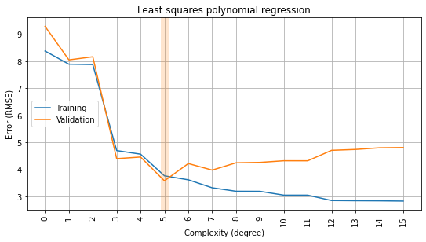

```python
def rmse(y_true, y_pred):
    return np.sqrt(mean_squared_error(y_true, y_pred))

def plot_fitting_graph(x, metric_train, metric_valid, xlabel, ylabel,
                       custom_metric=None, custom_label='', custom_scale='log', title='Fitting graph'):
    plt.figure(figsize=(9, 4.5))
    plt.plot(x, metric_train, label='Training')
    plt.plot(x, metric_valid, color='C1', label='Validation')
    plt.axvline(x[np.argmin(metric_valid)], color='C1', lw=10, alpha=0.2)
    plt.title(title)
    plt.xlabel(xlabel)
    plt.ylabel(ylabel)
    plt.grid(True)
    plt.xticks(x, rotation='vertical')
    plt.legend(loc='center left')
    if custom_metric:
        plt.twinx()
        plt.yscale(custom_scale)
        plt.plot(x, custom_metric, alpha=0.2, lw=4, ls='dotted', color='black', label=custom_label)
        plt.legend(loc='center right')
    plt.show()

rmse_train, rmse_valid = [], []
for degree in DEGREES:
    reg = make_model(degree).fit(X_train, y_train)
    rmse_train.append(rmse(reg.predict(X_train), y_train))
    rmse_valid.append(rmse(reg.predict(X_valid), y_valid))

plot_fitting_graph(DEGREES, rmse_train, rmse_valid, xlabel='Complexity (degree)', ylabel='Error (RMSE)',
                   title='Least squares polynomial regression')
```

### Sweet spot

What is the optimal `degree` to go with?

```python
DEGREES[np.argmin(rmse_valid)]
```

```
5
```

### Cross-validation

Ideally, we would choose the the model parameters such that we have the best model performance. However, we want to make sure that we really have the best validation performance. When we do `train_test_split` we randomly split the data into two parts. What could happen is that we got lucky and split the data such that it favours the validation error. This is especially dangerous if we are dealing with small datasets. One way to check if that's the case is to run the experiment several times for different, random splits. However, there is an even more systematic way of doing this: [cross-validation](https://scikit-learn.org/stable/modules/cross_validation.html).

[figure not shown]

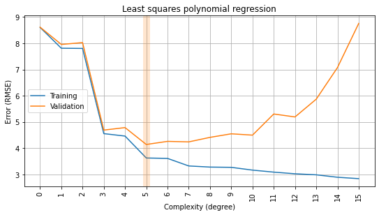

```python
rmse_train, rmse_valid = [], []
for degree in DEGREES:
    results = cross_validate(make_model(degree),
                             X, y, cv=5,
                             return_train_score=True,
                             scoring='neg_root_mean_squared_error')
    rmse_train.append(-np.mean(results['train_score']))
    rmse_valid.append(-np.mean(results['test_score']))

plot_fitting_graph(DEGREES, rmse_train, rmse_valid, xlabel='Complexity (degree)', ylabel='Error (RMSE)',
                   title='Least squares polynomial regression')
```

### Model coefficients

Let's inspect our regression model coefficients:

```python
(make_model(degree=1).fit(X_train, y_train)['reg'].coef_,
 make_model(degree=2).fit(X_train, y_train)['reg'].coef_,
 make_model(degree=5).fit(X_train, y_train)['reg'].coef_,
 make_model(degree=10).fit(X_train, y_train)['reg'].coef_)
```

```
(array([2.81292778]),
 array([2.80049884, 0.45166501]),
 array([ 30.87315584,   1.48752361, -54.60227825,  -1.63699842,
         26.62792933]),
 array([  33.63850705,  -41.86346242,  -70.48743112,  278.98853452,
          27.48125634, -656.36383501,   59.32988346,  651.64795186,
         -47.55728814, -233.48455138]))
```

Hmm... it looks like high degree polynomials are coming with much bigger regression coefficients.

We are going to plot the mean absolute value of $w_i$ as a function of degree to reveal the relationship:

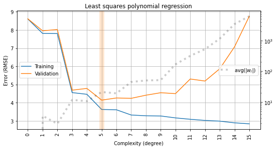

```python
rmse_train, rmse_valid, avg_coef = [], [], []
for degree in DEGREES:
    results = cross_validate(make_model(degree),
                             X, y, cv=5,
                             return_train_score=True, return_estimator=True,
                             scoring='neg_root_mean_squared_error')
    rmse_train.append(-np.mean(results['train_score']))
    rmse_valid.append(-np.mean(results['test_score']))
    avg_coef.append(
        # average over CV folds
        np.mean([
            # mean absolute value of weights
            np.mean(np.abs(model['reg'].coef_))
            for model in results['estimator']
        ]))

plot_fitting_graph(DEGREES, rmse_train, rmse_valid,
                   xlabel='Complexity (degree)', ylabel='Error (RMSE)',
                   custom_metric=avg_coef, custom_label='avg(|$w_i$|)',
                   title='Least squares polynomial regression')
```

### Summary

We observe the following:

1. **Underfitting** (degree < 5): The model is not able to fit the data properly. The fit is bad for both the training and the validation set.
2. **Fit is just right** (degree = 5): The model is able to capture the underlying data distribution. The fit is good for both the training and the validation set.
3. **Overfitting** (degree > 5): The model starts fitting the noise in the dataset. While the fit for the training data gets even better, the fit for the validation set gets worse.
4. As the order of polynomial increases, the linear model coefficients become more likely to take on **large values**.

## Part 2: Regularization

There are two major ways to build a machine learning model with the ability to generalize well on unseen data:

1. Train the simplest model possible for our purpose (according to Occam’s Razor).
2. Train a complex or more expressive model on the data and perform regularization.

Regularization is a method used to reduce the variance of a machine learning model. In other words, it is used to reduce overfitting. Regularization penalizes a model for being complex. For linear models, it means regularization forces model coefficients to be smaller in magnitude.

Let's pick a polynomial model of degree **15** (which tends to overfit strongly) and try to regularize it using **L1** and **L2** penalties.

### L1 - Lasso regression

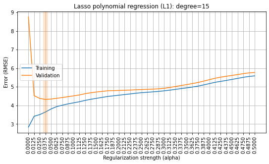

```python
rmse_train, rmse_valid = [], []
for alpha in ALPHAS:
    results = cross_validate(make_model(degree=15, penalty='L1', alpha=alpha),
                             X, y, cv=5,
                             return_train_score=True,
                             scoring='neg_root_mean_squared_error')
    rmse_train.append(-np.mean(results['train_score']))
    rmse_valid.append(-np.mean(results['test_score']))

plot_fitting_graph(ALPHAS, rmse_train, rmse_valid,
                   xlabel='Regularization strength (alpha)', ylabel='Error (RMSE)',
                   title='Lasso polynomial regression (L1): degree=15')
```

### L2 - Ridge regression

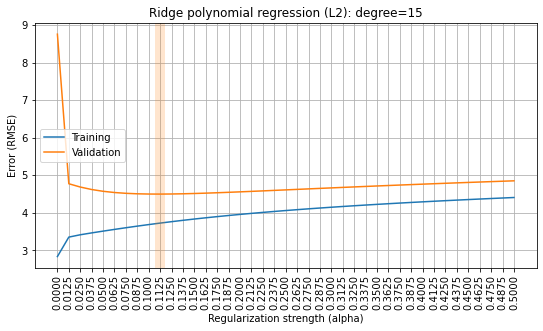

```python
rmse_train, rmse_valid = [], []
for alpha in ALPHAS:
    results = cross_validate(make_model(degree=15, penalty='L2', alpha=alpha),
                             X, y, cv=5,
                             return_train_score=True,
                             scoring='neg_root_mean_squared_error')
    rmse_train.append(-np.mean(results['train_score']))
    rmse_valid.append(-np.mean(results['test_score']))

plot_fitting_graph(ALPHAS, rmse_train, rmse_valid,
                   xlabel='Regularization strength (alpha)', ylabel='Error (RMSE)',
                   title='Ridge polynomial regression (L2): degree=15')
```

### Summary

1. We can control the regularization strength by changing the hyperparameter `alpha`.
2. Regularized version of the model performs pretty well. Even in case the original original (unregularized) model is heavily overfitting due to excessive complexity.

## Part 3: Homework assignment (10 points)

**WARNING!**

Due to the limited power of your machine, you may face some difficulties in generating polynomial features of a high degree. It's ok to take only a subsample of features for that purpose (even one feature is enough). Afterwards, you **must collect all features together** (those which were used to generate polynomials and the rest).

### Excercise 1 - Overfiting and Underfitting (2 points)

Let's work with the diabetes dataset

```python
from sklearn.datasets import load_diabetes
data = load_diabetes()
X_diabetes = pd.DataFrame(data['data'], columns=data['feature_names'])
y_diabetes = pd.DataFrame(data['target'], columns=['target'])
# print(data['DESCR'])
```

Apply model for diabetes dataset with polynomial feature engineering of different degrees. Plot the dependence of train and test error on polynomial degree. Highlight a degree with the best test error. Which degrees cause overfitting/underfitting? Why?

```python
X_train, X_valid, y_train, y_valid = train_test_split(X_diabetes, y_diabetes, test_size=0.2, random_state=SEED)
```

```python
X_train
```

|  | age | sex | bmi | bp | s1 | s2 | s3 | s4 | s5 | s6 |
| --- | --- | --- | --- | --- | --- | --- | --- | --- | --- | --- |
| 17 | 0.070769 | 0.050680 | 0.012117 | 0.056301 | 0.034206 | 0.049416 | -0.039719 | 0.034309 | 0.027368 | -0.001078 |
| 66 | -0.009147 | 0.050680 | -0.018062 | -0.033214 | -0.020832 | 0.012152 | -0.072854 | 0.071210 | 0.000271 | 0.019633 |
| 137 | 0.005383 | -0.044642 | 0.049840 | 0.097616 | -0.015328 | -0.016345 | -0.006584 | -0.002592 | 0.017037 | -0.013504 |
| 245 | -0.027310 | -0.044642 | -0.035307 | -0.029771 | -0.056607 | -0.058620 | 0.030232 | -0.039493 | -0.049868 | -0.129483 |
| 31 | -0.023677 | -0.044642 | -0.065486 | -0.081414 | -0.038720 | -0.053610 | 0.059685 | -0.076395 | -0.037128 | -0.042499 |
| ... | ... | ... | ... | ... | ... | ... | ... | ... | ... | ... |
| 106 | -0.096328 | -0.044642 | -0.076264 | -0.043542 | -0.045599 | -0.034821 | 0.008142 | -0.039493 | -0.059473 | -0.083920 |
| 270 | 0.005383 | 0.050680 | 0.030440 | 0.083844 | -0.037344 | -0.047347 | 0.015505 | -0.039493 | 0.008640 | 0.015491 |
| 348 | 0.030811 | -0.044642 | -0.020218 | -0.005671 | -0.004321 | -0.029497 | 0.078093 | -0.039493 | -0.010904 | -0.001078 |
| 435 | -0.012780 | -0.044642 | -0.023451 | -0.040099 | -0.016704 | 0.004636 | -0.017629 | -0.002592 | -0.038459 | -0.038357 |
| 102 | -0.092695 | -0.044642 | 0.028284 | -0.015999 | 0.036958 | 0.024991 | 0.056003 | -0.039493 | -0.005145 | -0.001078 |

353 rows × 10 columns

ColumnTransformer was added to the Pipeline in order to apply polinomial feature engineering to the selected features only:

```python
def make_model(degree, alpha=0, penalty=None):
    # linear regression
    if alpha == 0:
        regressor = LinearRegression()
    # lasso regression",
    elif penalty == 'L1':
        regressor = Lasso(alpha=alpha, random_state=SEED, max_iter=10000000, tol=0.0001)
    # ridge regression",
    elif penalty == 'L2':
        regressor = Ridge(alpha=alpha, random_state=SEED, max_iter=10000000, tol=0.0001)

    trf = ColumnTransformer([
        ('polynom', PolynomialFeatures(degree, include_bias=(degree == 0)), ['bmi'])
    ], remainder='passthrough')

    return Pipeline([
        ('pol', trf),
        ('sca', StandardScaler()),
        ('reg', regressor)
    ])

display(make_model(1))
display(make_model(2, penalty='L1', alpha=0.1))
display(make_model(2, penalty='L2', alpha=0.1))
```

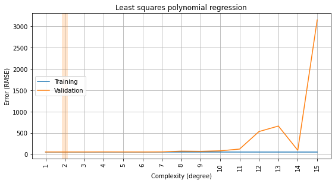

```python
DEGREES1 = np.delete(DEGREES, 0)

rmse_train, rmse_valid = [], []
for degree in DEGREES1:
    reg = make_model(degree).fit(X_train, y_train)
    rmse_train.append(rmse(reg.predict(X_train), y_train))
    rmse_valid.append(rmse(reg.predict(X_valid), y_valid))

plot_fitting_graph(DEGREES1, rmse_train, rmse_valid, xlabel='Complexity (degree)', ylabel='Error (RMSE)',
                   title='Least squares polynomial regression')
```

```python
DEGREES1[np.argmin(rmse_valid)]
```

```
2
```

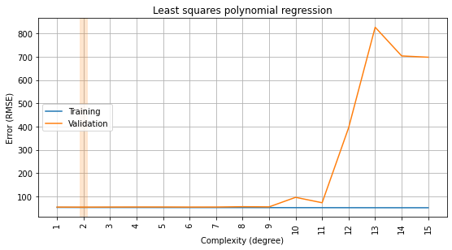

```python
# Cross-validation
rmse_train, rmse_valid = [], []
for degree in DEGREES1:
    results = cross_validate(make_model(degree),
                             X_diabetes, y_diabetes, cv=5,
                             return_train_score=True,
                             scoring='neg_root_mean_squared_error')
    rmse_train.append(-np.mean(results['train_score']))
    rmse_valid.append(-np.mean(results['test_score']))

plot_fitting_graph(DEGREES1, rmse_train, rmse_valid, xlabel='Complexity (degree)', ylabel='Error (RMSE)',
                   title='Least squares polynomial regression')
```

```python
DEGREES1[np.argmin(rmse_valid)]
```

```
2
```

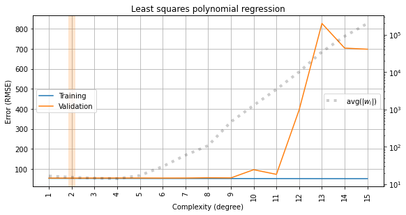

```python
rmse_train, rmse_valid, avg_coef = [], [], []
for degree in DEGREES1:
    results = cross_validate(make_model(degree),
                             X_diabetes, y_diabetes, cv=5,
                             return_train_score=True, return_estimator=True,
                             scoring='neg_root_mean_squared_error')
    rmse_train.append(-np.mean(results['train_score']))
    rmse_valid.append(-np.mean(results['test_score']))
    avg_coef.append(
        # average over CV folds
        np.mean([
            # mean absolute value of weights
            np.mean(np.abs(model['reg'].coef_))
            for model in results['estimator']
        ]))

plot_fitting_graph(DEGREES1, rmse_train, rmse_valid,
                   xlabel='Complexity (degree)', ylabel='Error (RMSE)',
                   custom_metric=avg_coef, custom_label='avg(|$w_i$|)',
                   title='Least squares polynomial regression')
```

The only feature that was polynomized is 'bmi' because computer power doesn't allow to fit model with polynomial feature engineering of high degrees.  
Cross-validation allows to reduce RMSE.  
The optimal degree to proceed is 2.

### Excercise 2 - Magnitude (3 points)

As discussed earlier, regularization methods are expected to constraint the weights (model coefficients).

Is it indeed happening?

Please do a discovery on your own and find that out empirically (both for **L1** and **L2**). Let's use `degree=15` and `alpha` from `ALPHAS`.

#### L1

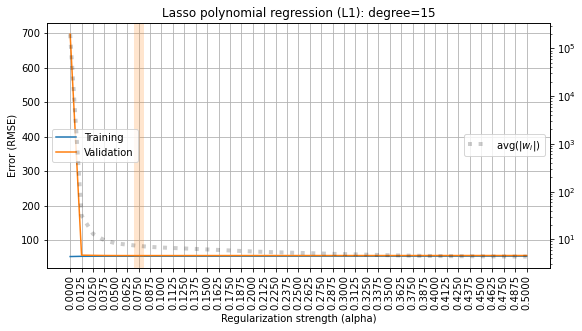

```python
rmse_train, rmse_valid, avg_coef = [], [], []
for alpha in ALPHAS:
    results = cross_validate(make_model(degree=15, penalty='L1', alpha=alpha),
                             X_diabetes, y_diabetes, cv=5,
                             return_train_score=True, return_estimator=True,
                             scoring='neg_root_mean_squared_error')
    rmse_train.append(-np.mean(results['train_score']))
    rmse_valid.append(-np.mean(results['test_score']))
    avg_coef.append(
        # average over CV folds
        np.mean([
            # mean absolute value of weights
            np.mean(np.abs(model['reg'].coef_))
            for model in results['estimator']
        ]))

plot_fitting_graph(ALPHAS, rmse_train, rmse_valid,
                   xlabel='Regularization strength (alpha)', ylabel='Error (RMSE)',
                   custom_metric=avg_coef, custom_label='avg(|$w_i$|)',
                   title='Lasso polynomial regression (L1): degree=15')
```

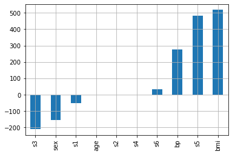

```python
lasso = Lasso(alpha = 0.1)
lasso.fit(X_diabetes, y_diabetes)
features = X_diabetes.columns
pd.Series(lasso.coef_, features).sort_values(ascending = True).plot(kind = "bar", grid=True);
```

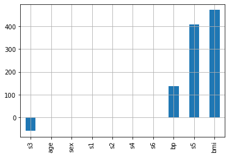

```python
lasso = Lasso(alpha = 0.5)
lasso.fit(X_diabetes, y_diabetes)
features = X_diabetes.columns
pd.Series(lasso.coef_, features).sort_values(ascending = True).plot(kind = "bar", grid=True);
```

#### L2

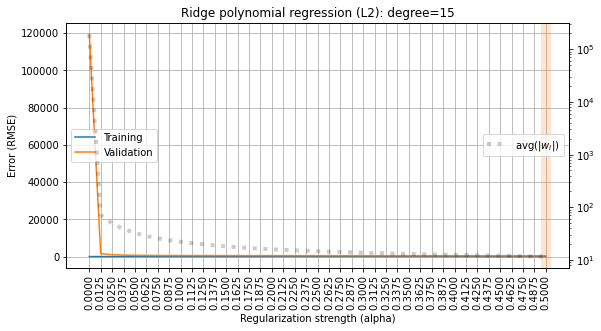

```python
rmse_train, rmse_valid, avg_coef = [], [], []
for alpha in ALPHAS:
    results = cross_validate(make_model(degree=15, penalty='L2', alpha=alpha),
                             X_diabetes, y_diabetes, cv=2,
                             return_train_score=True, return_estimator=True,
                             scoring='neg_root_mean_squared_error')
    rmse_train.append(-np.mean(results['train_score']))
    rmse_valid.append(-np.mean(results['test_score']))
    avg_coef.append(
        # average over CV folds
        np.mean([
            # mean absolute value of weights
            np.mean(np.abs(model['reg'].coef_))
            for model in results['estimator']
        ]))

plot_fitting_graph(ALPHAS, rmse_train, rmse_valid,
                   xlabel='Regularization strength (alpha)', ylabel='Error (RMSE)',
                   custom_metric=avg_coef, custom_label='avg(|$w_i$|)',
                   title='Ridge polynomial regression (L2): degree=15')
```

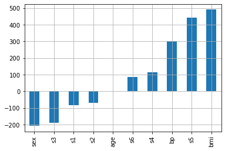

```python
ridge = Ridge(alpha = 0.1)
ridge.fit(X_diabetes, y_diabetes)
features = X_diabetes.columns
pd.Series(ridge.coef_[0], features).sort_values(ascending = True).plot(kind = "bar", grid=True);
```

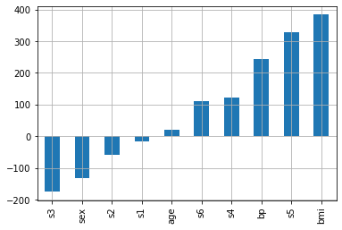

```python
ridge = Ridge(alpha = 0.5)
ridge.fit(X_diabetes, y_diabetes)
features = X_diabetes.columns
pd.Series(ridge.coef_[0], features).sort_values(ascending = True).plot(kind = "bar", grid=True);
```

#### Summary

- Ridge regression takes the square of the coefficients and lasso takes the magnitude.
- Lasso regression can be used for automatic feature selection, as the geometry of its constrained region allows coefficient values to inert to zero.
- The larger the alpha value, the more aggressive the penalization.

### Excercise 3 - Sparsity (3 points)

Lasso can also be used for **feature selection** since L1 is [more likely to produce zero coefficients](https://explained.ai/regularization/).

Is it indeed happening?

Please do a discovery on your own and find that out empirically (both for **L1** and **L2**). Let's use `degree=15` and `alpha` from `ALPHAS`.

#### L1

```python
count = 0
for alpha in ALPHAS:
    results = make_model(degree=15, penalty='L1', alpha=alpha).fit(X_diabetes, y_diabetes)
    count += np.count_nonzero(np.abs(results['reg'].coef_ == 0))
count
```

```
443
```

#### L2

```python
count = 0
for alpha in ALPHAS:
    results = make_model(degree=15, penalty='L2', alpha=alpha).fit(X_diabetes, y_diabetes)
    count += np.count_nonzero(np.abs(results['reg'].coef_ == 0))
count
```

```
0
```

#### Summary

The key difference between Ridge and Lasso regression is that Lasso Regression has the ability to nullify the impact of an irrelevant feature in the data, meaning that it can reduce the coefficient of a feature to zero thus completely eliminating it and hence is better at reducing the variance when the data consists of many insignificant features. Ridge regression, however, can not reduce the coefficients to absolute zero.

For degree equals 15 and different alphas Lasso regression produces 443 zero coefficients, Ridge regression doesn't produce any.

### Excercise 4 - Scaling (2 points)

As a general rule, it is recommended to scale input features before fitting a regularized model so that the features/inputs take values in similar ranges. One common way of doing so is to standardize the inputs and that is exactly what our pipeline second step (`StandardScaler`) is responsible for.

Is scaling important? What are the underlying reasons?

Please do a discovery on your own and find that out empirically (both for **L1** and **L2**) on the dataset below. Check coefficients.

```python
def target_function_hw(x):
    return 2 * x

def generate_samples_hw():
    np.random.seed(SEED)
    x = np.random.uniform(*RANGE, size=N_SAMPLES)

    np.random.seed(SEED+1)
    x_noise = np.random.uniform(*[x * 100 for x in RANGE], size=N_SAMPLES)
    x_noise2 = np.random.normal(100, 50, size=N_SAMPLES)

    y = target_function_hw(x) + np.random.normal(scale=4, size=N_SAMPLES)

    return np.concatenate([x.reshape(-1, 1) / 100,
                           x_noise.reshape(-1, 1),
                           x_noise2.reshape(-1, 1)], axis=1), y

X_hw, y_hw = generate_samples_hw()

for i in range(X_hw.shape[1]):
    print(f'Min of feature {i}: {min(X_hw[:, i]):.2f}, max: {max(X_hw[:, i]):.2f}')
```

```
Min of feature 0: -0.05, max: 0.05
Min of feature 1: -494.87, max: 493.57
Min of feature 2: -2.35, max: 213.31
```

Pipeline for model without scaling:

```python
def make_model_1(alpha=0, penalty=None):
    # lasso regression"
    if penalty == 'L1':
        regressor = Lasso(alpha=alpha, random_state=SEED, max_iter=50000)
    # ridge regression"
    elif penalty == 'L2':
        regressor = Ridge(alpha=alpha, random_state=SEED, max_iter=50000)

    return Pipeline([
        ('reg', regressor)
    ])

display(make_model_1(penalty='L1', alpha=0.1))
display(make_model_1(penalty='L2', alpha=0.1))
```

Pipeline for model with scaling:

```python
def make_model_2(alpha=0, penalty=None):
    # lasso regression"
    if penalty == 'L1':
        regressor = Lasso(alpha=alpha, random_state=SEED, max_iter=50000)
    # ridge regression"
    elif penalty == 'L2':
        regressor = Ridge(alpha=alpha, random_state=SEED, max_iter=50000)

    return Pipeline([
        ('sca', StandardScaler()),
        ('reg', regressor)
    ])

display(make_model_2(penalty='L1', alpha=0.1))
display(make_model_2(penalty='L2', alpha=0.1))
```

Defining function **rmse_coeff** to calculate and print RMSE and model coefficients:

```python
def rmse_coeff(regularization, scaling, X, y):
    X_train, X_valid, y_train, y_valid = train_test_split(X, y, test_size=0.2, random_state=SEED)
    if scaling == False:
        model = make_model_1(alpha=0.1, penalty=regularization)
    elif scaling == True:
        model = make_model_2(alpha=0.1, penalty=regularization)
    coefficients = model.fit(X_train, y_train)['reg'].coef_
    predict_train = model.predict(X_train)
    predict_test = model.predict(X_valid)
    print('RMSE on train data: ', mean_squared_error(y_train, predict_train)**(0.5))
    print('RMSE on test data: ',  mean_squared_error(y_valid, predict_test)**(0.5))
    print('Model coefficients: ',  coefficients)
```

#### L1

```python
# Model without data scaling
rmse_coeff(regularization='L1', scaling=False, X=X_hw, y=y_hw)
```

```
RMSE on train data:  5.172178818441987
RMSE on test data:  5.1109266392859825
Model coefficients:  [ 6.69268632e+01 -1.43754838e-03 -2.80423123e-02]
```

```python
# Model with data scaling
rmse_coeff(regularization='L1', scaling=True, X=X_hw, y=y_hw)
```

```
RMSE on train data:  3.947008728127226
RMSE on test data:  4.274486268741438
Model coefficients:  [ 5.27992611 -0.11351952 -1.09351337]
```

#### L2

```python
# Model without data scaling
rmse_coeff(regularization='L2', scaling=False, X=X_hw, y=y_hw)
```

```
RMSE on train data:  5.574161753849243
RMSE on test data:  5.357178859459
Model coefficients:  [ 4.70843497e+01 -1.57253709e-03 -2.87828228e-02]
```

```python
# Model with data scaling
rmse_coeff(regularization='L2', scaling=True, X=X_hw, y=y_hw)
```

```
RMSE on train data:  3.9435439378942925
RMSE on test data:  4.3787476576724
Model coefficients:  [ 5.35475871 -0.20703342 -1.18533272]
```

#### Summary

Feature Scaling is a technique to standardize the independent features present in the data in a fixed range. It is performed during the data pre-processing to handle highly varying magnitudes or values or units.

As we can see, in both cases (Ridge and Lasso) RMSE for models with scaling is less than for moels without scaling.

So coefficients must be scaled to the same unit of measure to retrieve feature importance. Scaling them with the standard-deviation of the feature is a useful approach.